# Estudo de Caso - Bellabeat

Gabriel Amazonas Cury

2025-03-26

## Introdução

Esse estudo de caso foi desenvolvido com base no projeto final de análise de dados do Google. Este trabalho tem como objetivo explorar e extrair insights a partir dos dados coletados por dispositivos Fitbit, com foco em compreender os hábitos diários relacionados à atividade física, ao padrão de sono e ao sedentarismo dos usuários.

Em um cenário onde saúde e bem-estar estão cada vez mais no centro das atenções, entender essas métricas torna-se essencial para a tomada de decisões estratégicas. A partir desta análise, pretende-se extrair insights para os stakholders da Bellabeat e contribuir para o entendimento do comportamento dos usuários.

## 1. Perguntas Principais

Nesta fase, o foco está em compreender as interrogações e necessidades dos stakeholders. Para isso, o objetivo é extrair insights a partir do conjunto de dados dos dispositivos inteligentes da Fitbit, visando entender o comportamento dos usuários e melhorar sua experiência com a Bellabeat.

- Quais são as tendências emergentes no uso de dispositivos inteligentes?
- Como essas tendências se aplicam aos clientes da Bellabeat?
- De que maneira esses insights podem influenciar a estratégia de marketing da Bellabeat?

### 1.1 Stakeholders Principais

- Urška Sršen: Cofundadora e CEO da Bellabeat
- Sando Mur: Matemático, cofundador e membro-chave da equipe executiva

É fundamental, além disso, alinhar este projeto com a equipe de marketing, garantindo que os resultados possam ser efetivamente aplicados em estratégias comerciais.

## 2. Preparação dos Dados

Foi utilizado o conjunto de dados do Fitbit Fitness Tracker, disponível sob a licença CC0 (domínio público) e fornecido pelo Mobius. Esses dados foram coletados via Amazon Mechanical Turk e representam apenas uma parcela dos usuários, o que pode introduzir algum viés na análise. Contudo, a procedência dos dados é confiável, permitindo a exploração inicial de correlações e tendências.

Link para o Conjunto: [Kaggle - Fitbit Dataset](https://www.kaggle.com/datasets/arashnic/fitbit?resource=download)

Todos os usuários consentiram com a coleta dos dados pessoais do dispositivo, incluindo informações de atividade física em nível de minuto, frequência cardíaca e monitoramento do sono.

## 3. Processamento dos Dados

Para a limpeza e análise dos dados, optou-se por utilizar a linguagem R. Essa escolha se deve à necessidade de melhorar minhas habilidades de programação. Outras ferramentas poderiam ter sido utilizadas, como as planilhas e linguagens de consulta estruturadas, mas, preferencialmente gosto de usar uma linguagem de programação.

### 3.1 Preparando o Ambiente

Antes de começar a limpeza e análise de dados, é de suma importância instalar e carregar os pacotes utilizados.

```r
install.packages("tidyverse")
install.packages("janitor")
library(tidyverse)
library(janitor)
```

```r
library(ggplot2)
```

Agora é importante carregar os arquivos csv utilizados no projeto em dataframes. Eles poderão ser encontrados no dataset baixado.

```r
atividade_diaria <- read.csv("atividade_diaria.csv")
dia_de_sono <- read.csv("dia_de_sono.csv")
```

### 3.2 Ideia Geral e Limpeza dos Dados

Antes de começar efetivamente a limpeza dos dados, é importante ter uma ideia geral do dataset.

```r
head(atividade_diaria)
```

```
##           Id ActivityDate TotalSteps TotalDistance TrackerDistance
## 1 1503960366    4/12/2016      13162          8.50            8.50
## 2 1503960366    4/13/2016      10735          6.97            6.97
## 3 1503960366    4/14/2016      10460          6.74            6.74
## 4 1503960366    4/15/2016       9762          6.28            6.28
## 5 1503960366    4/16/2016      12669          8.16            8.16
## 6 1503960366    4/17/2016       9705          6.48            6.48
##   LoggedActivitiesDistance VeryActiveDistance ModeratelyActiveDistance
## 1                        0               1.88                     0.55
## 2                        0               1.57                     0.69
## 3                        0               2.44                     0.40
## 4                        0               2.14                     1.26
## 5                        0               2.71                     0.41
## 6                        0               3.19                     0.78
##   LightActiveDistance SedentaryActiveDistance VeryActiveMinutes
## 1                6.06                       0                25
## 2                4.71                       0                21
## 3                3.91                       0                30
## 4                2.83                       0                29
## 5                5.04                       0                36
## 6                2.51                       0                38
##   FairlyActiveMinutes LightlyActiveMinutes SedentaryMinutes Calories
## 1                  13                  328              728     1985
## 2                  19                  217              776     1797
## 3                  11                  181             1218     1776
## 4                  34                  209              726     1745
## 5                  10                  221              773     1863
## 6                  20                  164              539     1728
```

```r
head(dia_de_sono)
```

```
##           Id              SleepDay TotalSleepRecords TotalMinutesAsleep
## 1 1503960366 4/12/2016 12:00:00 AM                 1                327
## 2 1503960366 4/13/2016 12:00:00 AM                 2                384
## 3 1503960366 4/15/2016 12:00:00 AM                 1                412
## 4 1503960366 4/16/2016 12:00:00 AM                 2                340
## 5 1503960366 4/17/2016 12:00:00 AM                 1                700
## 6 1503960366 4/19/2016 12:00:00 AM                 1                304
##   TotalTimeInBed
## 1            346
## 2            407
## 3            442
## 4            367
## 5            712
## 6            320
```

```r
colnames(atividade_diaria)
```

```
##  [1] "Id"                       "ActivityDate"
##  [3] "TotalSteps"               "TotalDistance"
##  [5] "TrackerDistance"          "LoggedActivitiesDistance"
##  [7] "VeryActiveDistance"       "ModeratelyActiveDistance"
##  [9] "LightActiveDistance"      "SedentaryActiveDistance"
## [11] "VeryActiveMinutes"        "FairlyActiveMinutes"
## [13] "LightlyActiveMinutes"     "SedentaryMinutes"
## [15] "Calories"
```

```r
colnames(dia_de_sono)
```

```
## [1] "Id"                 "SleepDay"           "TotalSleepRecords"
## [4] "TotalMinutesAsleep" "TotalTimeInBed"
```

Os nomes das colunas são limpas e renomeadas para garantir a consistência dos dados.

```r
atividade_diaria <- atividade_diaria %>%
  clean_names() %>% rename(
    data = activity_date,
    passos_totais = total_steps,
    distancia_total = total_distance,
    distancia_do_rastreador = tracker_distance,
    distancia_das_atividades_registradas = logged_activities_distance,
    distancia_muito_ativa = very_active_distance,
    distancia_moderadamente_ativa = moderately_active_distance,
    distancia_levemente_ativa = light_active_distance,
    distancia_ativa_sedentaria = sedentary_active_distance,
    minutos_muito_ativos = very_active_minutes,
    minutos_razoavelmente_ativos = fairly_active_minutes,
    minutos_pouco_ativos = lightly_active_minutes,
    minutos_sedentarios = sedentary_minutes,
    calorias = calories)

dia_de_sono <- dia_de_sono %>%
  clean_names() %>% rename(
    dia_do_sono = sleep_day,
    registros_de_sono_total = total_sleep_records,
    total_minutos_dormindo = total_minutes_asleep,
    tempo_total_na_cama = total_time_in_bed
  )
```

Ao limpar valores é importante remover quaisquer duplicatas e dados ausentes.

```r
atividade_diaria <- atividade_diaria %>%
  drop_na() %>%
  distinct()

dia_de_sono <- dia_de_sono %>%
  drop_na() %>%
  distinct()
```

## 4. Análise dos Dados

Nessa etapa utiliza-se conhecimentos estatísticos para analisar os dados para obter insights para as partes interessadas.

### 4.1 Estatísticas Básicas

```r
summary(atividade_diaria)
```

```
##        id                data           passos_totais   distancia_total
##  Min.   :1.504e+09   Length:940         Min.   :    0   Min.   : 0.000
##  1st Qu.:2.320e+09   Class :character   1st Qu.: 3790   1st Qu.: 2.620
##  Median :4.445e+09   Mode  :character   Median : 7406   Median : 5.245
##  Mean   :4.855e+09                      Mean   : 7638   Mean   : 5.490
##  3rd Qu.:6.962e+09                      3rd Qu.:10727   3rd Qu.: 7.713
##  Max.   :8.878e+09                      Max.   :36019   Max.   :28.030
##  distancia_do_rastreador distancia_das_atividades_registradas
##  Min.   : 0.000          Min.   :0.0000
##  1st Qu.: 2.620          1st Qu.:0.0000
##  Median : 5.245          Median :0.0000
##  Mean   : 5.475          Mean   :0.1082
##  3rd Qu.: 7.710          3rd Qu.:0.0000
##  Max.   :28.030          Max.   :4.9421
##  distancia_muito_ativa distancia_moderadamente_ativa distancia_levemente_ativa
##  Min.   : 0.000        Min.   :0.0000                Min.   : 0.000
##  1st Qu.: 0.000        1st Qu.:0.0000                1st Qu.: 1.945
##  Median : 0.210        Median :0.2400                Median : 3.365
##  Mean   : 1.503        Mean   :0.5675                Mean   : 3.341
##  3rd Qu.: 2.053        3rd Qu.:0.8000                3rd Qu.: 4.782
##  Max.   :21.920        Max.   :6.4800                Max.   :10.710
##  distancia_ativa_sedentaria minutos_muito_ativos minutos_razoavelmente_ativos
##  Min.   :0.000000           Min.   :  0.00       Min.   :  0.00
##  1st Qu.:0.000000           1st Qu.:  0.00       1st Qu.:  0.00
##  Median :0.000000           Median :  4.00       Median :  6.00
##  Mean   :0.001606           Mean   : 21.16       Mean   : 13.56
##  3rd Qu.:0.000000           3rd Qu.: 32.00       3rd Qu.: 19.00
##  Max.   :0.110000           Max.   :210.00       Max.   :143.00
##  minutos_pouco_ativos minutos_sedentarios    calorias
##  Min.   :  0.0        Min.   :   0.0      Min.   :   0
##  1st Qu.:127.0        1st Qu.: 729.8      1st Qu.:1828
##  Median :199.0        Median :1057.5      Median :2134
##  Mean   :192.8        Mean   : 991.2      Mean   :2304
##  3rd Qu.:264.0        3rd Qu.:1229.5      3rd Qu.:2793
##  Max.   :518.0        Max.   :1440.0      Max.   :4900
```

```r
summary(dia_de_sono)
```

```
##        id            dia_do_sono        registros_de_sono_total
##  Min.   :1.504e+09   Length:410         Min.   :1.00
##  1st Qu.:3.977e+09   Class :character   1st Qu.:1.00
##  Median :4.703e+09   Mode  :character   Median :1.00
##  Mean   :4.995e+09                      Mean   :1.12
##  3rd Qu.:6.962e+09                      3rd Qu.:1.00
##  Max.   :8.792e+09                      Max.   :3.00
##  total_minutos_dormindo tempo_total_na_cama
##  Min.   : 58.0          Min.   : 61.0
##  1st Qu.:361.0          1st Qu.:403.8
##  Median :432.5          Median :463.0
##  Mean   :419.2          Mean   :458.5
##  3rd Qu.:490.0          3rd Qu.:526.0
##  Max.   :796.0          Max.   :961.0
```

Embora haja diferentes recomendações sobre o número ideal de passos diários, a discrepância entre a média e o valor máximo sugere que há espaço para incentivar um aumento na atividade física.

Além disso, notou-se que os usuários tendem a registrar distâncias mais curtas e tempo reduzido em atividade física, o que pode ser indicativo de um comportamento mais sedentário. Análises adicionais serão necessárias para correlacionar esses dados com outros padrões de saúde.

### 4.2 Correlação: Passos Totais x Calorias

A correlação entre o total de passos e as calorias queimadas foi de 0,59 (valor arredondado para duas casas decimais), sugerindo uma relação moderada a forte: quanto mais passos, maior a queima calórica.

```r
cor(atividade_diaria$passos_totais, atividade_diaria$calorias)
```

```
## [1] 0.5915681
```

O gráfico de dispersão, com a sobreposição de uma reta de regressão (linha laranja), confirma essa tendência positiva. Contudo, observou-se que alguns pontos, especialmente daqueles com mais de 20 mil passos, não apresentaram um aumento proporcional na queima de calorias, indicando a influência de outros fatores (por exemplo, metabolismo individual).

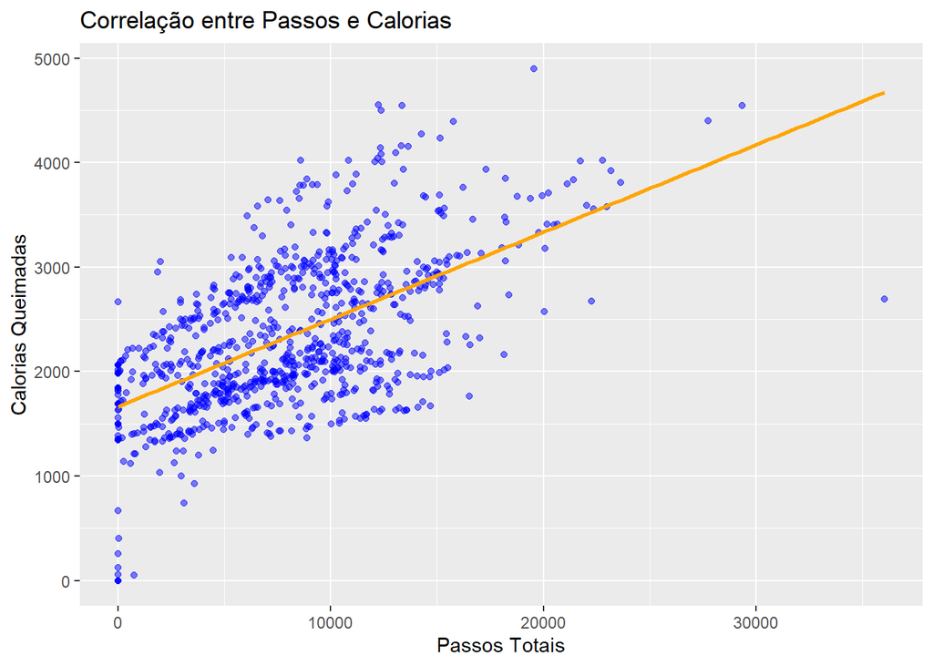

```r
ggplot(atividade_diaria, mapping = aes(x = passos_totais, y = calorias)) +
  geom_point(color = "blue", alpha = 0.5) +
  labs(title = "Correlação entre Passos e Calorias",
       x = "Passos Totais", y = "Calorias Queimadas") +
  geom_smooth(method = "lm", color = "orange", se = FALSE)
```

### 4.3 Análise: Minutos Ativos Totais x Minutos Sedentários

Foi criada uma coluna que agrupa os minutos ativos totais, somando todas as frações de tempo em atividade física. Calculou-se, então, o percentual de sedentarismo ao relacionar os minutos sedentários com o total de minutos registrados.

```r
atividade_diaria <- atividade_diaria %>%
  mutate(minutos_ativos_totais = minutos_muito_ativos +
           minutos_razoavelmente_ativos + minutos_pouco_ativos) %>%
  mutate(
    percentual_sedentario = (minutos_sedentarios / (minutos_ativos_totais +
                                                    minutos_sedentarios)) * 100)
```

A partir do histograma gerado com esses percentuais, constatou-se que a faixa de sedentarismo concentra-se entre 70% e 100%, reforçando a ideia de que os usuários monitorados apresentam uma rotina predominantemente sedentária.

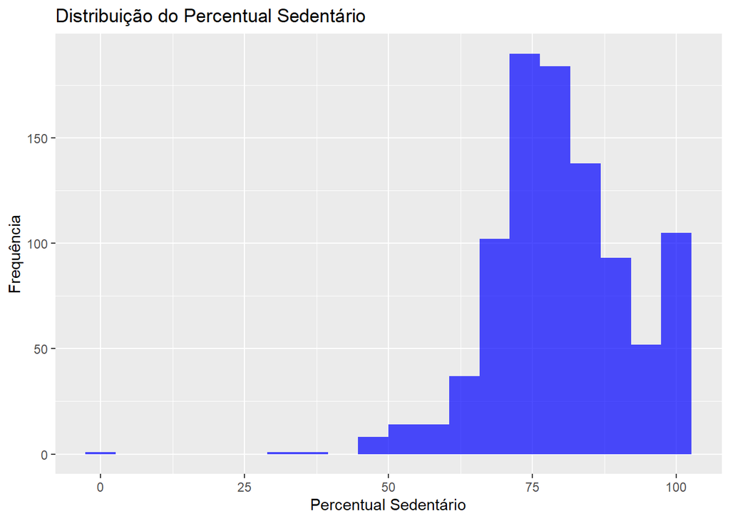

```r
ggplot(atividade_diaria, mapping = aes(x = percentual_sedentario)) +
  geom_histogram(fill = "blue", alpha = 0.7, bins = 20) +
  labs(title = "Distribuição do Percentual Sedentário",
       x = "Percentual Sedentário", y = "Frequência")
```

### 4.4 Correlação: Passos Totais x Minutos Dormidos

Antes de fazer essa análise era necessário combinar os dataframes para fazer essa relação. Com isso, era importante fazer algumas formatações para garantir uma intersecção adequada. Precisou-se separar a data e hora e formatar no tipo adequado para combinar os dados em id e data.

```r
dia_de_sono <- dia_de_sono %>%
  separate(dia_do_sono, into = c("data", "hora"), sep = " ")
dia_de_sono$data <- as.Date(dia_de_sono$data, format = "%m/%d/%Y")
atividade_diaria$data <- as.Date(atividade_diaria$data, format = "%m/%d/%Y")

df_combinado <- inner_join(atividade_diaria, dia_de_sono, by = c("id", "data"))
```

Voltando à análise, a expectativa inicial era de uma correlação positiva entre o total de passos e os minutos de sono. Contudo, os resultados mostraram uma correlação negativa e fraca, sugerindo que, à medida que os passos aumentam, os minutos dormidos tendem a diminuir — embora o efeito seja discreto.

```r
cor(df_combinado$passos_totais, df_combinado$total_minutos_dormindo)
```

```
## [1] -0.1903439
```

O gráfico de dispersão demonstrou uma relação linear muito sutil, com um coeficiente angular pequeno, indicando que os passos totais não são um bom preditor de uma melhor qualidade de sono. Outros fatores provavelmente influenciam os padrões de sono dos usuários.

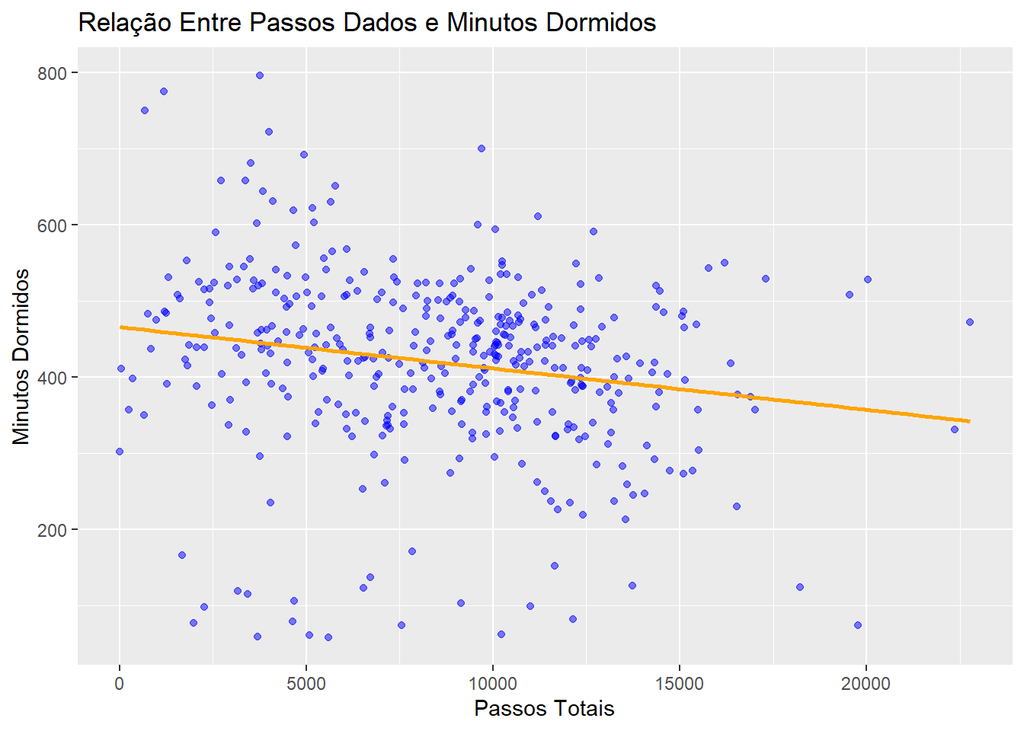

```r
ggplot(df_combinado, mapping = aes(x = passos_totais,
                                   y = total_minutos_dormindo)) +
  geom_point(color = "blue", alpha = 0.5) +
  labs(title = "Relação Entre Passos Dados e Minutos Dormidos",
                      x = "Passos Totais", y = "Minutos Dormidos") +
  geom_smooth(method = "lm", se = FALSE, color = "orange")
```

### 4.5 Eficiência do Sono e Relação com Minutos Ativos

Precisou-se criar uma nova coluna com o cálculo da eficiência do sono dos usuários. Ela foi calculada, levando em consideração o tempo dormido e o tempo na cama.

```r
df_combinado <- df_combinado %>%
  mutate(eficiencia_do_sono = (total_minutos_dormindo / tempo_total_na_cama) *
           100)
```

A eficiência do sono dos usuários situa-se entre 90% e 100%, o que significa que a maior parte do tempo na cama é realmente dedicada ao sono. Apesar desse índice elevado, uma alta eficiência não necessariamente se traduz em uma qualidade de sono superior. Pode ocorrer que, mesmo obtendo boa eficiência, a qualidade do sono seja comprometida por um estilo de vida sedentário. É possível que pessoas com altos níveis de sedentarismo consigam “otimizar” o tempo de sono sem, contudo, alcançar uma qualidade de descanso ideal. Esse cenário sugere um potencial benefício em direcionar esforços para o aumento da atividade física, contribuindo para uma melhor qualidade de vida. Esse valor pode ser verificado no histograma abaixo.

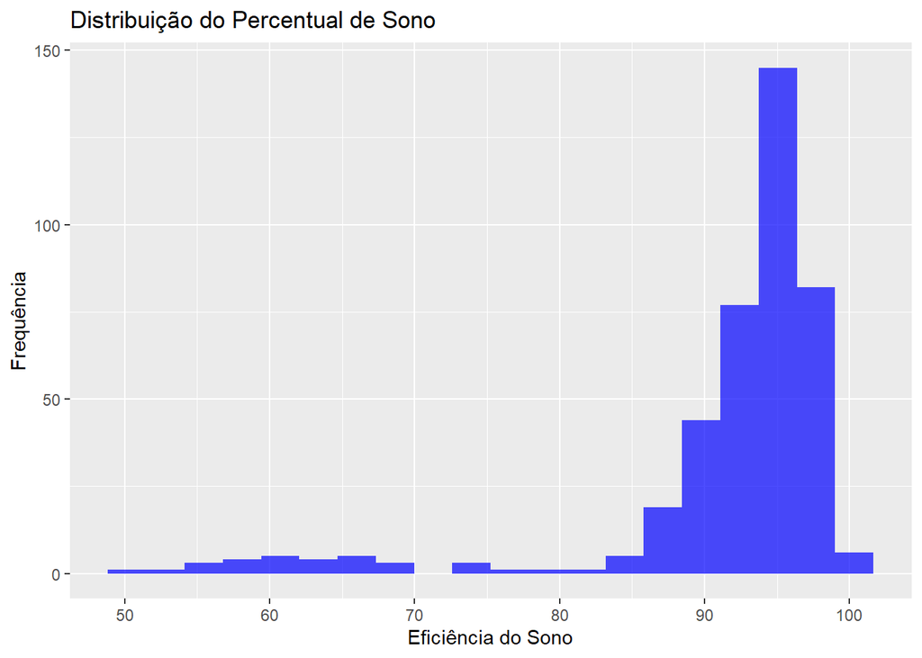

```r
ggplot(df_combinado, mapping = aes(x = eficiencia_do_sono)) +
  geom_histogram(fill = "blue", alpha = 0.7, bins = 20) +
  labs(title = "Distribuição do Percentual de Sono", x = "Eficiência do Sono",
       y = "Frequência")
```

## 5. Conclusão

A partir da análise dos dados coletados dos dispositivos Fitbit, alguns pontos críticos apareceram, oferecendo insights valiosos que podem orientar a estratégia de produto e marketing da Bellabeat.

### 5.2 Relação entre Atividade e Queima de Calorias

A correlação moderada a forte (0,59) entre passos totais e calorias queimadas reforça a ideia de que aumentar a atividade física pode trazer benefícios concretos na melhoria do gasto calórico. Contudo, a existência de outliers, usuários que, mesmo com elevada contagem de passos, não queimam calorias na expectativa esperada, sugere a necessidade de um olhar mais detalhado para fatores individuais, como metabolismo e composição corporal. Essa incerteza destaca a importância de oferecer recomendações personalizadas, possibilitando à Bellabeat diferenciar sua oferta por meio de insights baseados em dados personalizados.

### 5.3 Sono e Qualidade de Descanso

Embora a análise mostre uma alta eficiência de sono (entre 90% e 100%), o fato de os usuários serem altamente sedentários pode indicar problemas relacionados à qualidade do sono, mesmo que o tempo na cama seja bem aproveitado. Além disso, a relação fraca e negativa entre passos e minutos dormidos sugere que o aumento da atividade física não necessariamente está correlacionado a um maior tempo de sono. Essa complexidade implica que a Bellabeat pode se beneficiar ao aprofundar a investigação dos fatores que influenciam a qualidade do sono, considerando intervenções que promovam um equilíbrio saudável entre atividade e descanso.

### 5.4 Aplicações Estratégicas e de Marketing

Os insights obtidos reforçam a necessidade de produtos e campanhas que incentivem um estilo de vida mais ativo e equilibrado. A Bellabeat pode, por exemplo, explorar:

- Personalização de Recomendações: Utilizar os dados para oferecer sugestões individualizadas de atividades físicas e rotinas para melhorar a qualidade do sono, considerando as particularidades de cada usuário.
- Campanhas de Engajamento: Desenvolver iniciativas que incentivem a quebra do padrão sedentário, comunicando os benefícios para a saúde e bem-estar, e diferenciando a marca por seu compromisso com a qualidade de vida.
- Aprimoramento de Produtos: Integrar funcionalidades que monitorem não apenas a quantidade, mas também a qualidade dos exercícios e do sono, proporcionando uma visão mais holística da saúde do usuário.
- Disponibilização das Métricas: As métricas de análise de cada usuário poderiam ser disponibilizadas para eles entenderem como estão se saindo de acordo com sua rotina estabelecida. Isso confere uma maior transparência de acordo com a realidade dos usuários.
- Gameficação da Plataforma: Poderia ser desenvolvido técnicas de gameficação para os usuários se manterem engajados com suas atividades diárias. Por exemplo: um guia passo a passo a partir da rotina do usuário poderia integrá-lo aos poucos nesse novo estilo de vida, até eles se acostumarem, aumentando gradativamente sua atividade física. Além disso, é importante transmitir uma sensação de recompensa ao usuário através de conquistas. Isso os mantém em seu progresso.

## 6. Agradecimentos

Esse foi o meu primeiro estudo de caso. Obrigado a você que dedicou um tempo para ler esse projeto. Estou disposto a discutí-lo mais, caso queira. Além disso, estarei aberto à novas análises, críticas e sugestões.